# Music Genre Classification

Based on Song Sentiment

Aleksandra Gawor, Paulina Kułakowska

## 1. Introduction

#### 1.1. Research questions

In this paper we aim to utilize text mining, NLP and sentimental analysis to mine for patterns in associating the sentiments within a song with its genre. Is it possible to associate the mood of a song with the genre? Are some words more popular for a certain genre and appear more frequently? Is it possible to predict the genre basing only on the sentiment of a song and its lyrics?

#### 1.2. Literature overview

## 2. Methodology

#### 2.1. Data set

For the sake of analysis, we used Kaggle’s dataset 380,000+ lyrics from MetroLyrics. The initial data consisted of 339277 observations of 6 variables. Our dataset is a sample of 20000 rows.

#### 2.2. Text preprocessing

The first step was to draw a sample from our data and remove subspaces that were included in our data set.

```r
### draw data sample
data.sample <- data[sample(nrow(data), 20000),]

lyrics <- subset(data.sample, data.sample != "")
```

Then, we did a tokenization, which breaks the text into individual tokens and transforms it into a data structure, in our case, unnested into a word–i.e. extracting words from lyrics.

```r
lyrics <- lyrics %>% unnest_tokens(word, lyrics)
```

After tokenization it was time to remove all weird characters from the newly created “word” column.  
Because some songs included special or foreign language characters there was a need to get rid of them. Also, we needed to exclude some typical for lyrics phrases, like “chorus”, “verse” etc.

```r
lyrics <- lyrics %>%
  filter(!str_detect(word,"a"),
         word != "â",
         word != "à",
         word != "la",
         word != "de",
         word != "chorus",
         word != "oh",
         word != "ooh",
         word != "woo",
         word != "verse",
         word != "yeah",
         word != "uh",
         word != "x2",
         word != "2x",
         word != "x3",
         word != "x4",
         word != "ho"
         )
```

It was also important to get rid of numbers and stop words. These two factors do not have any influance on our analysis, so it was not neccessary not to include them.

```r
# remove numbers
lyrics$word <- replace_number(lyrics$word, num.paste = FALSE, remove = TRUE)
```

```r
# remove stop words
lyrics <- lyrics %>% anti_join(stop_words)
```

Our songs in the dataset included also stop words not only from English but also from other foreign language songs. There was, therefore, a need to remove Spanish and French stop words as well.

```r
custom_stop_words1 <- bind_rows(stop_words,
                               data_frame(word = quanteda::stopwords("spanish"),
                                          lexicon = "custom"))
custom_stop_words2 <- bind_rows(stop_words,
                               data_frame(word = quanteda::stopwords("french"),
                                          lexicon = "custom"))


lyrics <- lyrics %>%
  anti_join(custom_stop_words1)
lyrics <- lyrics %>%
  anti_join(custom_stop_words2)
lyrics <- lyrics %>%
  mutate(word = iconv(word, from = "latin1", to = "ASCII")) %>%
  filter(!is.na(word))
```

We could also apply word stemming to cut off endings of words with similar meaning and thus also same sentiment. However, the same word in different form may be important for our analysis, and we decided to keep them.

```r
# possible word stemming
# lyrics$word <-SnowballC::wordStem(lyrics[[6]], language = 'en')
```

All the rows in the database have complete cases and no missing values. Then, we were able to find most popular words.

```r
data.words.count <- lyrics %>% count(word, sort=T)
kable(head(data.words.count))
```

| word | n |
| --- | --- |
| love | 17532 |
| time | 9939 |
| life | 6489 |
| feel | 6387 |
|  | 5655 |
| night | 5162 |

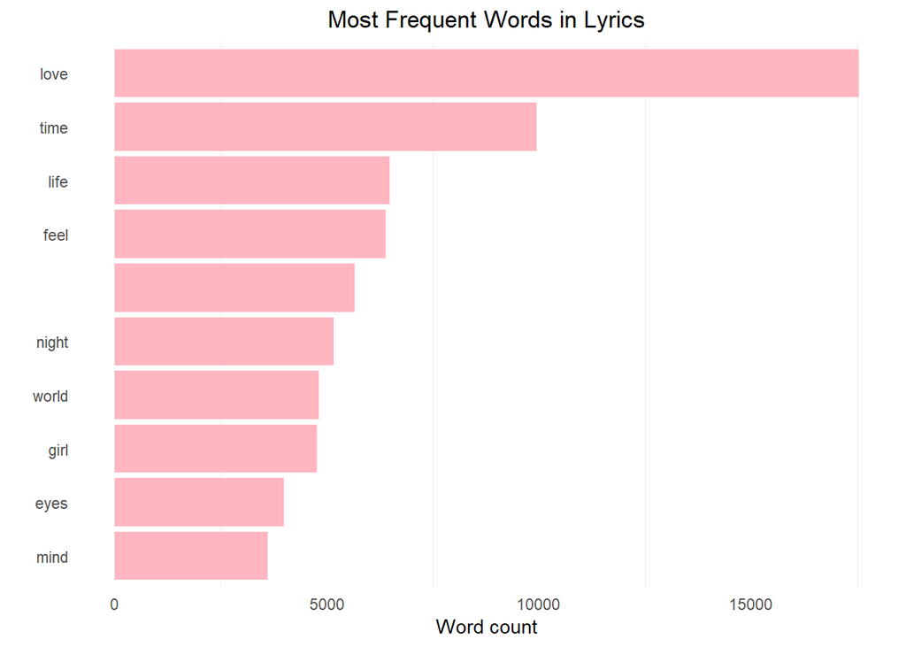

```r
# most frequent words
lyrics %>%
  count(word, sort = TRUE) %>%
  top_n(10) %>%
  ungroup() %>%
  mutate(word = reorder(word, n)) %>%
  ggplot() +
  geom_col(aes(word, n), fill = "lightpink") +
  theme_minimal() +
  theme(legend.position = "none",
        plot.title = element_text(hjust = 0.5),
        panel.grid.major = element_blank()) +
  xlab("") +
  ylab("Word count") +
  ggtitle("Most Frequent Words in Lyrics") +
  coord_flip()
```

We can clearly see, that the most popular word in music is “love”. But what is “love” usually connected with?

```r
lyrics_bigrams <- lyrics %>% unnest_tokens(bigram, word, token = "ngrams", n=2)

bigrams_sep <- lyrics_bigrams %>% separate(bigram, c("word1", "word2"), sep=" ")

bigrams_fil <- bigrams_sep %>%
filter(!word1 %in% stop_words$word) %>%
filter(!word2 %in% stop_words$word)

bigram_counts <- bigrams_fil %>%
count(word1, word2, sort = TRUE)

# finding most common connotations with love on first and second place

bigram_counts %>% filter(word1 == "love")
```

```
## # A tibble: 2,329 x 3
##    word1 word2       n
##    <chr> <chr>   <int>
##  1 love  love     3491
##  2 love  time      310
##  3 love  feel      269
##  4 love  life      256
##  5 love  girl      236
##  6 love  night     196
##  7 love  true      170
##  8 love  forever   166
##  9 love  hold      133
## 10 love  world     120
## # ... with 2,319 more rows
```

```r
bigram_counts %>% filter(word2 == "love")
```

```
## # A tibble: 2,390 x 3
##    word1   word2     n
##    <chr>   <chr> <int>
##  1 love    love   3491
##  2 feel    love    339
##  3 girl    love    283
##  4 time    love    274
##  5 true    love    261
##  6 life    love    205
##  7 night   love    179
##  8 world   love    169
##  9 sweet   love    113
## 10 forever love    108
## # ... with 2,380 more rows
```

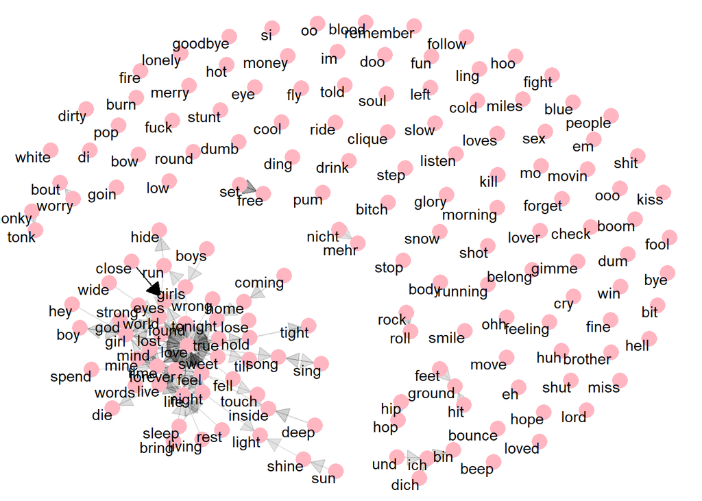

```r
bigram_graph <- bigram_counts %>%
  filter(n > 70) %>%
  graph_from_data_frame()

set.seed(123456)
a <- grid::arrow(type = "closed", length = unit(.15, "inches"))

ggraph(bigram_graph, layout = "fr") +
  geom_edge_link(aes(edge_alpha = n), show.legend = FALSE,
                 arrow = a, end_cap = circle(.07, 'inches')) +
  geom_node_point(color = "lightpink", size = 5) +
  geom_node_text(aes(label = name), vjust = 1, hjust = 1) +
  theme_void()
```

Our next step was to group all the data according to the column that contained name of the song.

```r
lyrics <- lyrics %>%
  group_by(song)
```

#### 2.3. Mood labelling and sentimental analysis

Our goal was to see most popular words by positive or negative sentiment.

```r
data.positive.negative <- lyrics %>% inner_join(get_sentiments("bing")) %>% count(word, sentiment, sort = T) %>% ungroup()
```

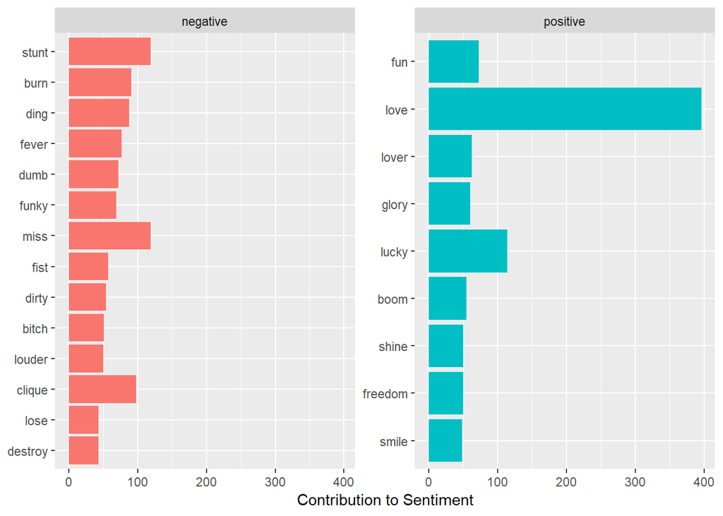

```r
data.positive.negative %>% group_by(sentiment) %>%
  top_n(15) %>%
  ungroup() %>%
  mutate(word = reorder(word, n)) %>%
  ggplot(aes(word, n, fill = sentiment)) +
  geom_col(show.legend = F) +
  facet_wrap(~ sentiment, scales = "free_y") +
  labs(y = "Contribution to Sentiment", x = NULL) +
  coord_flip()
```

Next step was to look into our data also in a form of a wordcloud, which also visualizes the negative and postive distinction.

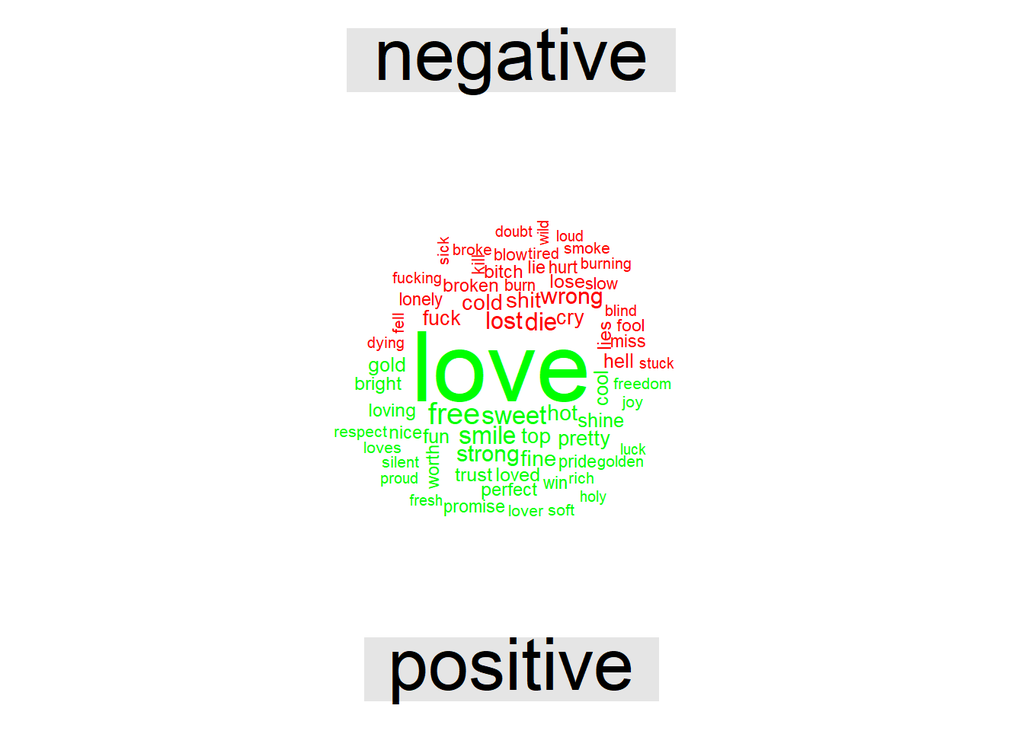

```r
lyrics %>%
  inner_join(get_sentiments("bing")) %>%
  count(word, sentiment, sort=TRUE) %>%
  acast(word ~ sentiment, value.var = "n", fill = 0) %>%
  comparison.cloud(colors = c("red", "green"),
                   max.words=70)
```

We can also find most frequent words across genres. For that, we again used the wordcloud, yet with several groups. In this part of the project we needed to get rid of ‘Not Avalibale’ and ‘Other’ types from genre.

```r
lyrics <-lyrics[!(lyrics$genre=="Not Available"),]
lyrics <-lyrics[!(lyrics$genre=="Other"),]

lyrics <- na.omit(lyrics)
```

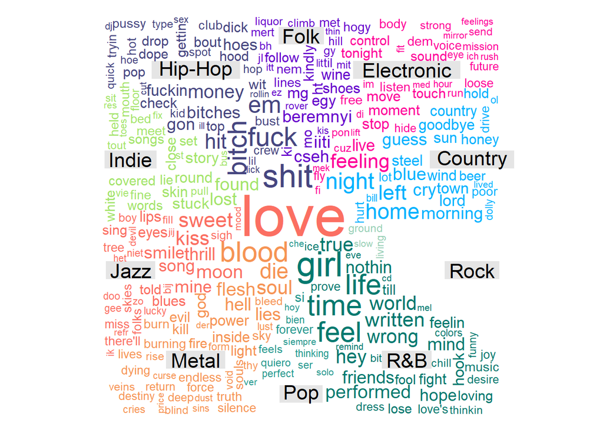

```r
# several groups (genres) wordcloud

lyrics %>%
  count(word, genre, sort=TRUE) %>%
  acast(word ~ genre, value.var = "n", fill = 0) %>%
  comparison.cloud(colors = c("#00B2FF", "#FF0099", "#6600CC","#464680",
                              "#a4e46b", "#fb6f62","#f69454", "#24978d","#01796f","#96ceb4",
                              "#ffeead","#ffad60","#5bc0de"),
                   max.words=1000,title.size=1.4)
```

After finding the most popular words, we focused on sentiment analysis of emotions in lyrics.  
We decided to use library nrc for sentimens of fear, anger and joy.

```r
# fear

nrcfear <- get_sentiments("nrc") %>% filter(sentiment == "fear")
lyrics %>% inner_join(nrcfear) %>% count(word, sort=T)
```

```
## # A tibble: 23,630 x 3
## # Groups:   song [8,600]
##    song                     word      n
##    <chr>                    <chr> <int>
##  1 fever                    fever    77
##  2 rebel-of-the-underground rebel    64
##  3 benz-friendz-watchutola  bitch    51
##  4 lose-yourself-to-dance   lose     43
##  5 running-with-the-devil   devil    42
##  6 wie-maak-die-jol-vol     die      42
##  7 wise-up-ghost            ghost    42
##  8 on-the-dancefloor        fire     40
##  9 fire-ant                 fire     38
## 10 move-bitch               bitch    38
## # ... with 23,620 more rows
```

```r
# joy

nrcjoy <- get_sentiments("nrc") %>% filter(sentiment == "joy")
lyrics %>% inner_join(nrcjoy) %>% count(word, sort=T)
```

```
## # A tibble: 25,746 x 3
## # Groups:   song [9,472]
##    song                              word      n
##    <chr>                             <chr> <int>
##  1 what-if-i-was-white               white   170
##  2 i-love-you                        love     99
##  3 have-fun                          fun      73
##  4 what-is-love                      love     69
##  5 if-you-re-not-gonna-love-me-right love     64
##  6 lover                             lover    63
##  7 wild-love                         love     60
##  8 sex-drive                         sex      57
##  9 blood-money                       money    56
## 10 got-caught-dealin                 money    52
## # ... with 25,736 more rows
```

```r
# anger

nrcanger <- get_sentiments("nrc") %>% filter(sentiment == "anger")
lyrics %>% inner_join(nrcanger) %>% count(word, sort=T)
```

```
## # A tibble: 22,660 x 3
## # Groups:   song [8,229]
##    song                     word         n
##    <chr>                    <chr>    <int>
##  1 rebel-of-the-underground rebel       64
##  2 blood-money              money       56
##  3 got-caught-dealin        money       52
##  4 benz-friendz-watchutola  bitch       51
##  5 lose-yourself-to-dance   lose        43
##  6 running-with-the-devil   devil       42
##  7 move-bitch               bitch       38
##  8 i-m-hot                  hot         35
##  9 prisoner                 prisoner    33
## 10 mayhem                   bout        32
## # ... with 22,650 more rows
```

What may be interesting is to find the prevailing emotions for each of genres. In which music genre song lyrics are the saddest or most joyful?

```r
sentiments <- lyrics %>%
  inner_join(get_sentiments("nrc"))  %>%
  filter(!sentiment %in% c("positive", "negative"))
```

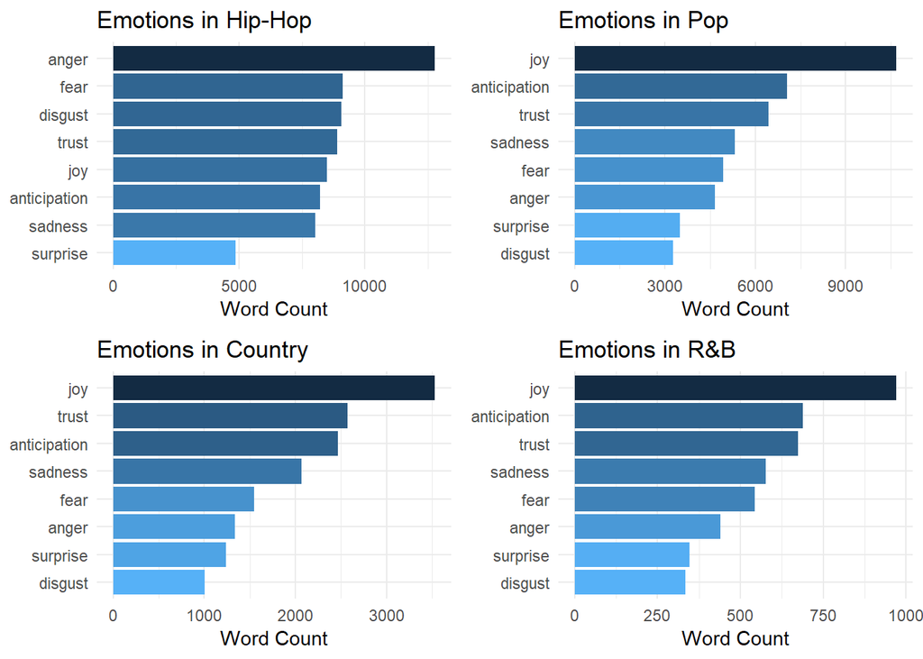

```r
plot1 <- sentiments %>%
  filter(genre %in% "Hip-Hop") %>%
  group_by(sentiment) %>%
  summarise(word_count = n()) %>%
  ungroup() %>%
  mutate(sentiment = reorder(sentiment, word_count)) %>%
  ggplot(aes(sentiment, word_count, fill = -word_count)) +
  geom_col() +
  guides(fill = FALSE) +
  theme_minimal() +
  labs(x = NULL, y = "Word Count") +
  ggtitle("Emotions in Hip-Hop") +
  coord_flip()

plot2 <- sentiments %>%
  filter(genre %in% "Pop") %>%
  group_by(sentiment) %>%
  summarise(word_count = n()) %>%
  ungroup() %>%
  mutate(sentiment = reorder(sentiment, word_count)) %>%
  ggplot(aes(sentiment, word_count, fill = -word_count)) +
  geom_col() +
  guides(fill = FALSE) +
  theme_minimal() +
  labs(x = NULL, y = "Word Count") +
  ggtitle("Emotions in Pop") +
  coord_flip()

plot3 <- sentiments %>%
  filter(genre %in% "Country") %>%
  group_by(sentiment) %>%
  summarise(word_count = n()) %>%
  ungroup() %>%
  mutate(sentiment = reorder(sentiment, word_count)) %>%
  ggplot(aes(sentiment, word_count, fill = -word_count)) +
  geom_col() +
  guides(fill = FALSE) +
  theme_minimal() +
  labs(x = NULL, y = "Word Count") +
  ggtitle("Emotions in Country") +
  coord_flip()

plot4 <- sentiments %>%
  filter(genre %in% "R&B") %>%
  group_by(sentiment) %>%
  summarise(word_count = n()) %>%
  ungroup() %>%
  mutate(sentiment = reorder(sentiment, word_count)) %>%
  ggplot(aes(sentiment, word_count, fill = -word_count)) +
  geom_col() +
  guides(fill = FALSE) +
  theme_minimal() +
  labs(x = NULL, y = "Word Count") +
  ggtitle("Emotions in R&B") +
  coord_flip()

grid.arrange(plot1, plot2, plot3, plot4, ncol = 2)
```

The most negative sentiments we can find in the Hip-Hop music, while the genre of Pop has much more words associated with rather good emotions. Sentiments most prevalent in Hip-Hop music are the ones of anger, fear and disgust. Also, many vulgar, profanity words come mostly from Hip-Hop lyrics and are also included in the top negative words from our “Contribution to Sentiment” graph and wordclouds. The Hip-Hop genre as well as Pop may be groups that would be easy to classify by the sentiment (polarity) predictor.

The Chord Diagram enabled us to visualize the inter-relationships between each genre and emotion.

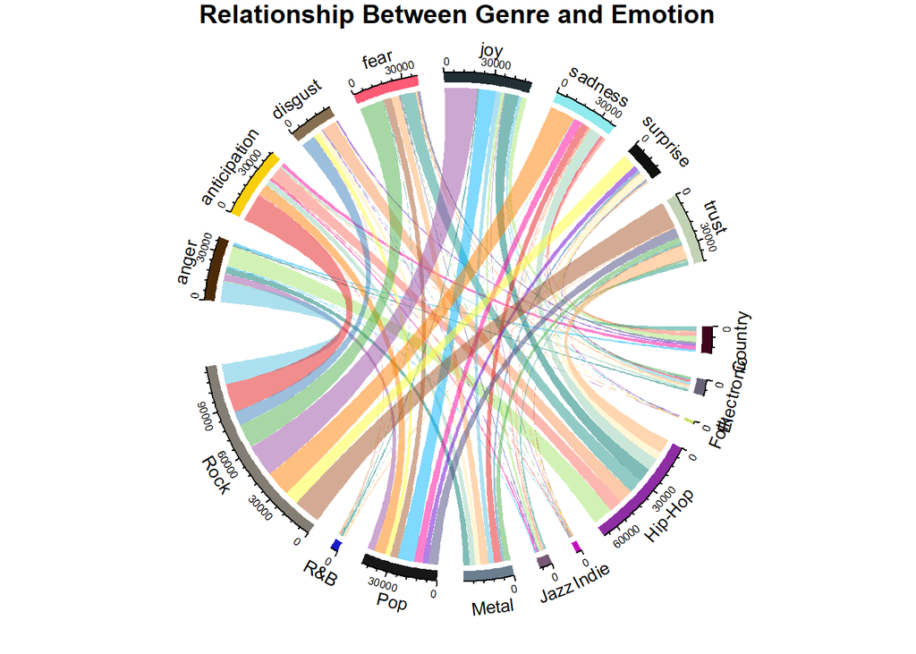

```r
sentiments <- lyrics %>%
  inner_join(get_sentiments("nrc"),by="word")

genre_emotion <- sentiments %>%
  filter(!sentiment %in% c("positive", "negative")) %>%
  count(sentiment, genre) %>%
  group_by(genre, sentiment) %>%
  summarise(sentiment_sum = sum(n)) %>%
  ungroup()


colors <- c("#00B2FF", "#FF0099", "#6600CC","#464680",
            "#a4e46b", "#fb6f62","#f69454", "#24978d","#01796f","#96ceb4",
            "#ffeead","#ffad60","#5bc0de", "#E41A1C", "#377EB8", "#4DAF4A",
            "#984EA3", "#FF7F00", "#FFFF33", "#A65628")

circos.clear()

#Setting the gap size
circos.par(gap.after = c(rep(6, length(unique(genre_emotion[[1]])) - 1), 15,
                         rep(6, length(unique(genre_emotion[[2]])) - 1), 15))

chordDiagram(genre_emotion, col = colors)
title("Relationship Between Genre and Emotion")
```

## 3. Classification

#### 3.1. Extracting polarity

```r
# Positive / negative ratios and polarity

lyrics_bing <- lyrics %>%
  inner_join(get_sentiments("bing"))
lyrics_polarity <- lyrics_bing %>%
  count(sentiment, song) %>%
  spread(sentiment, n, fill = 0) %>%
  mutate(polarity = positive - negative,
         percent_positive = positive / (positive + negative) * 100,
         percent_negative = negative / (positive + negative) * 100)

# we only need 'genre' variable as well
lyrics_genre <- lyrics %>% select(c("song", "genre"))

# drop duplicates (we are interested in whole song, not observations for each word)
lyrics_song <- unique(lyrics_genre)

# now we are ready to combine the two sets of variables
lyrics_set <- merge(lyrics_song, lyrics_polarity, by = "song")

# we set the genre to factor, to read it as a response variable
lyrics_set$genre <- as.factor(lyrics_set$genre)
```

#### 3.2. Genre polarity and sentiment visualization

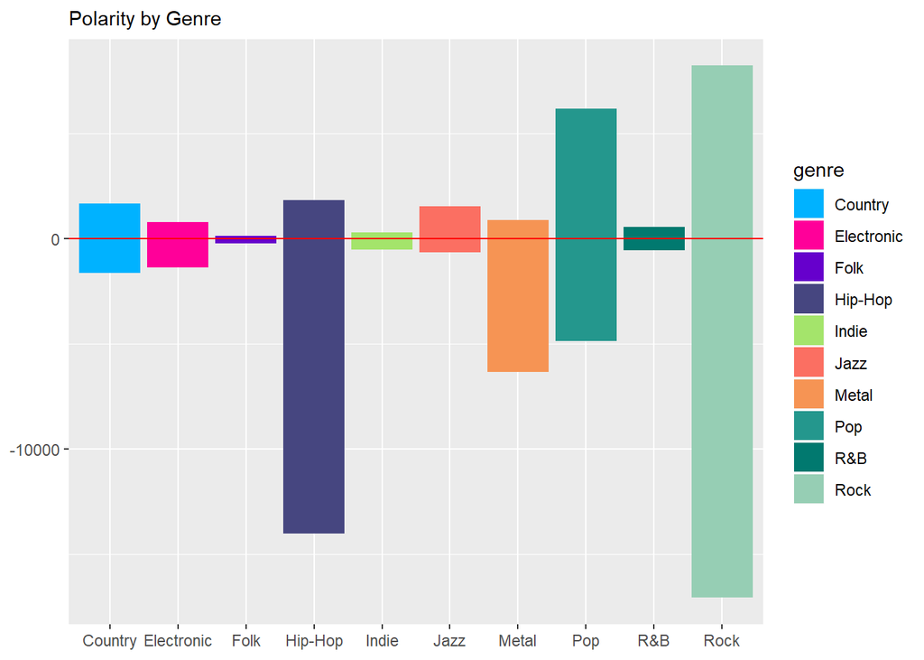

```r
# Genre polarity visualization
lyrics_set %>%
  ggplot( aes(genre, polarity, fill = genre)) +
  geom_col() +
  scale_fill_manual(values = colors) +
  geom_hline(yintercept = 0, color = "red") +
  theme(plot.title = element_text(size = 11)) +
  xlab(NULL) + ylab(NULL) +
  ggtitle("Polarity by Genre")
```

#### 3.2. Support Vector Machine

```r
set.seed(123456)
training_obs <- createDataPartition(lyrics_set$genre,
                                    p = 0.7,
                                    list = FALSE)
lyrics.train <- lyrics_set[training_obs,]
lyrics.test  <- lyrics_set[-training_obs,]

# Defining the model formula and training the model
svm.model <- svm(genre ~ negative + positive + polarity + percent_positive + percent_negative,
                 data = lyrics.train)

summary(svm.model)
```

```
##
## Call:
## svm(formula = genre ~ negative + positive + polarity + percent_positive +
##     percent_negative, data = lyrics.train)
##
##
## Parameters:
##    SVM-Type:  C-classification
##  SVM-Kernel:  radial
##        cost:  1
##       gamma:  0.2
##
## Number of Support Vectors:  6379
##
##  ( 2052 1295 872 533 817 67 110 124 261 248 )
##
##
## Number of Classes:  10
##
## Levels:
##  Country Electronic Folk Hip-Hop Indie Jazz Metal Pop R&B Rock
```

```r
svm.pred <- predict(svm.model, lyrics.test)

cm.svm <- confusionMatrix(svm.pred, lyrics.test$genre)
cm.svm
```

```
## Confusion Matrix and Statistics
##
##             Reference
## Prediction   Country Electronic Folk Hip-Hop Indie Jazz Metal  Pop  R&B
##   Country          0          0    0       0     0    0     0    0    0
##   Electronic       0          0    0       0     0    0     0    0    0
##   Folk             0          0    0       0     0    0     0    0    0
##   Hip-Hop          4         12    1     131     2    4    23   27    2
##   Indie            0          0    0       0     0    0     0    0    0
##   Jazz             0          0    0       0     0    0     0    0    0
##   Metal            0          0    0       0     0    0     0    0    0
##   Pop              1          2    0       7     0    3     2   14    1
##   R&B              0          0    0       0     0    0     0    0    0
##   Rock           223         92   27     261    44  104   324  514   50
##             Reference
## Prediction   Rock
##   Country       0
##   Electronic    0
##   Folk          0
##   Hip-Hop      65
##   Indie         0
##   Jazz          0
##   Metal         0
##   Pop           7
##   R&B           0
##   Rock       1534
##
## Overall Statistics
##
##                Accuracy : 0.4823
##                  95% CI : (0.4656, 0.4991)
##     No Information Rate : 0.4614
##     P-Value [Acc > NIR] : 0.006887
##
##                   Kappa : 0.09
##  Mcnemar's Test P-Value : NA
##
## Statistics by Class:
##
##                      Class: Country Class: Electronic Class: Folk
```

[output cut: 11 more lines]

```
## Pos Pred Value              0.48339          NaN         NaN          NaN
## Neg Pred Value              0.91651      0.98679     0.96811       0.8997
## Prevalence                  0.11462      0.01321     0.03189       0.1003
## Detection Rate              0.03763      0.00000     0.00000       0.0000
## Detection Prevalence        0.07785      0.00000     0.00000       0.0000
## Balanced Accuracy           0.64145      0.50000     0.50000       0.5000
##                      Class: Pop Class: R&B Class: Rock
## Sensitivity            0.025225    0.00000      0.9552
## Specificity            0.992139    1.00000      0.1259
## Pos Pred Value         0.378378        NaN      0.4835
## Neg Pred Value         0.842915    0.98477      0.7662
## Prevalence             0.159437    0.01523      0.4614
## Detection Rate         0.004022    0.00000      0.4407
## Detection Prevalence   0.010629    0.00000      0.9115
## Balanced Accuracy      0.508682    0.50000      0.5405
```

```r
# Is it any better when taking only the polarity?
svm.model.2 <- svm(genre ~ polarity,
                 data = lyrics.train)

svm.pred.2 <- predict(svm.model.2, lyrics.test)

cm.svm.2 <- confusionMatrix(svm.pred.2, lyrics.test$genre)
cm.svm.2
```

```
## Confusion Matrix and Statistics
##
##             Reference
## Prediction   Country Electronic Folk Hip-Hop Indie Jazz Metal  Pop  R&B
##   Country          0          0    0       0     0    0     0    0    0
##   Electronic       0          0    0       0     0    0     0    0    0
##   Folk             0          0    0       0     0    0     0    0    0
##   Hip-Hop          3          8    1     102     2    1    23   21    1
##   Indie            0          0    0       0     0    0     0    0    0
##   Jazz             0          0    0       0     0    0     0    0    0
##   Metal            0          0    0       0     0    0     0    0    0
##   Pop              2          3    0       5     0    6     2   21    2
##   R&B              0          0    0       0     0    0     0    0    0
##   Rock           223         95   27     292    44  104   324  513   50
##             Reference
## Prediction   Rock
##   Country       0
##   Electronic    0
##   Folk          0
##   Hip-Hop      53
##   Indie         0
##   Jazz          0
##   Metal         0
##   Pop          13
##   R&B           0
##   Rock       1540
##
## Overall Statistics
##
##                Accuracy : 0.4777
##                  95% CI : (0.461, 0.4945)
##     No Information Rate : 0.4614
##     P-Value [Acc > NIR] : 0.02743
##
##                   Kappa : 0.0752
##  Mcnemar's Test P-Value : NA
##
## Statistics by Class:
##
##                      Class: Country Class: Electronic Class: Folk
```

[output cut: 11 more lines]

```
## Pos Pred Value              0.47442          NaN         NaN          NaN
## Neg Pred Value              0.90906      0.98679     0.96811       0.8997
## Prevalence                  0.11462      0.01321     0.03189       0.1003
## Detection Rate              0.02930      0.00000     0.00000       0.0000
## Detection Prevalence        0.06176      0.00000     0.00000       0.0000
## Balanced Accuracy           0.60949      0.50000     0.50000       0.5000
##                      Class: Pop Class: R&B Class: Rock
## Sensitivity            0.037838    0.00000      0.9589
## Specificity            0.988722    1.00000      0.1083
## Pos Pred Value         0.388889        NaN      0.4795
## Neg Pred Value         0.844179    0.98477      0.7546
## Prevalence             0.159437    0.01523      0.4614
## Detection Rate         0.006033    0.00000      0.4424
## Detection Prevalence   0.015513    0.00000      0.9227
## Balanced Accuracy      0.513280    0.50000      0.5336
```

```r
# What could be the reason?--the data may be highly unbalanced
prop.table(table(lyrics_set$genre))
```

```
##
##     Country  Electronic        Folk     Hip-Hop       Indie        Jazz
## 0.065496170 0.030467338 0.008176263 0.114639814 0.013426285 0.032016525
##       Metal         Pop         R&B        Rock
## 0.100352870 0.159221964 0.015233669 0.460969102
```

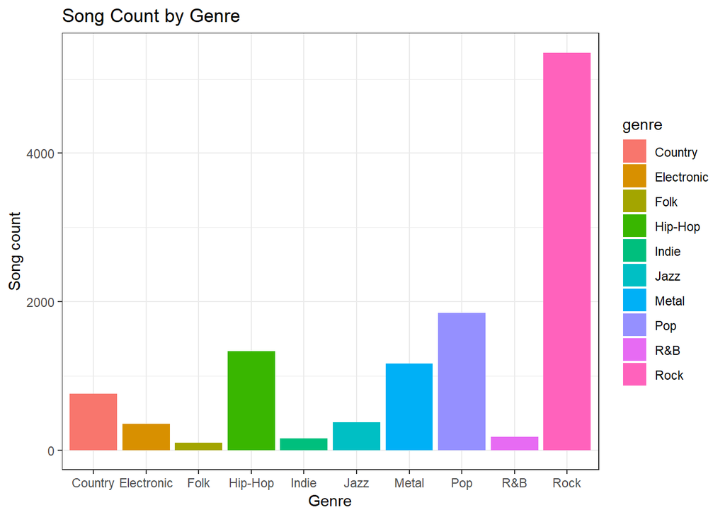

```r
lyrics_set$prop <- as.character.factor(lyrics_set$genre)
lyrics_set$prop <- within(lyrics_set, genre[genre == 'Country'] <- 'Country')
prop <- lyrics_set$prop

# Proportion visualization

ggplot(prop, aes(x = genre, fill = genre))+
  theme_bw()+
  geom_bar()+
  labs(x = "Genre", y = "Song count", title = "Song Count by Genre")
```